# First test of BioMark for enzyme assays

Copyright (C) 2018 Martin Engqvist Lab

## Experiment

This is an initial test where the instruments sensitivity toward the two dyes is tested. We are also interested in the linearety of the detection. The two dyes are fluorescein (FAM channel) and resurofin (ROX channel). Resurofin is the fluorescent molecule that will be produced in our enzyme reactions from an amplex red precursor. The fluorescein will act as a loading control in later experiments. The resurofin is actually the product that our enzymes will produce if active. In addition to this we are unsure of the Tween and Triton concentrations to be used so we test using either 0.1% or 0.01% (v/v) of both detergents on both the assay and substrate sides. Fluorescein was loaded on the assay side and resurofin was loaded on the sample side.

```r
#make sure the packages are installed
wants <- c('dplyr', 'reshape2', 'ggplot2')
has   <- wants %in% rownames(installed.packages())
if(any(!has)) install.packages(wants[!has], repos="http://ftp.acc.umu.se/mirror/CRAN/")

#load all the packages
lapply(wants, require, character.only = TRUE)
```

```
## [[1]]
## [1] TRUE
##
## [[2]]
## [1] TRUE
##
## [[3]]
## [1] TRUE
```

```r
#find the "code" directory, this should be one folder away from the project root
while (basename(getwd()) != 'code'){
  setwd("../")
  if (getwd() == '/'){
    quit(status = 1)
  }
}

#go one folder up and set as project root directory
setwd("../")
PROJ <- getwd()
setwd(paste0(PROJ, '/data/'))

#set folder paths relative to the project root
CURRENT <- getwd()
DATA <- getwd()
RAW_EXTERNAL <- paste0(DATA, '/raw_external/')
RAW_INTERNAL <- paste0(DATA, '/raw_internal/')
INTERMEDIATE = paste0(DATA, '/intermediate/')
FINAL = paste0(DATA, '/final/')

RESULTS <- paste0(PROJ, '/results/')
FIGURES <- paste0(RESULTS, 'figures/')
PICTURES <- paste0(RESULTS, 'pictures/')
```

## Setup

Let’s input the experimental paramenters for sample and assay sides

```r
# Test 1

assay.df <- data.frame('assay_well'=c('A01','A02','A03','A04','A05','A06','A07','A08','A09','A10','A11','A12'),
                       'assay_tween_conc'=c(0.01, 0.01, 0.01, 0.01, 0.01, 0.01, 0.1, 0.1, 0.1, 0.1, 0.1, 0.1),
                       'assay_tween_unit'=c('% (v/v)', '% (v/v)', '% (v/v)', '% (v/v)', '% (v/v)', '% (v/v)', '% (v/v)', '% (v/v)', '% (v/v)', '% (v/v)', '% (v/v)', '% (v/v)'),
                       'assay_triton_conc'=c(0.01, 0.01, 0.01, 0.01, 0.01, 0.01, 0.1, 0.1, 0.1, 0.1, 0.1, 0.1),
                       'assay_triton_unit'=c('% (v/v)', '% (v/v)', '% (v/v)', '% (v/v)', '% (v/v)', '% (v/v)', '% (v/v)', '% (v/v)', '% (v/v)', '% (v/v)', '% (v/v)', '% (v/v)'),
                       'assay_fluorescein_conc'=c(0.0, 1.0, 5.0, 10.0, 50.0, 100.0, 0.0, 1.0, 5.0, 10.0, 50.0, 100.0),
                       'assay_fluorescein_unit'=c('uM', 'uM', 'uM', 'uM', 'uM', 'uM', 'uM', 'uM', 'uM', 'uM', 'uM', 'uM'),
                       'assay_resurofin_conc'=c(0.0, 0.0, 0.0, 0.0, 0.0, 0.0, 0.0, 0.0, 0.0, 0.0, 0.0, 0.0),
                       'assay_resurofin_unit'=c('uM', 'uM', 'uM', 'uM', 'uM', 'uM', 'uM', 'uM', 'uM', 'uM', 'uM', 'uM'))


sample.df <- data.frame('sample_well'=c('S01','S02','S03','S04','S05','S06','S07','S08','S09','S10','S11','S12'),
                        'sample_tween_conc'=c(0.01, 0.01, 0.01, 0.01, 0.01, 0.01, 0.1, 0.1, 0.1, 0.1, 0.1, 0.1),
                        'sample_tween_unit'=c('% (v/v)', '% (v/v)', '% (v/v)', '% (v/v)', '% (v/v)', '% (v/v)', '% (v/v)', '% (v/v)', '% (v/v)', '% (v/v)', '% (v/v)', '% (v/v)'),
                        'sample_triton_conc'=c(0.01, 0.01, 0.01, 0.01, 0.01, 0.01, 0.1, 0.1, 0.1, 0.1, 0.1, 0.1),
                        'sample_triton_unit'=c('% (v/v)', '% (v/v)', '% (v/v)', '% (v/v)', '% (v/v)', '% (v/v)', '% (v/v)', '% (v/v)', '% (v/v)', '% (v/v)', '% (v/v)', '% (v/v)'),
                        'sample_fluorescein_conc'=c(0.0, 0.0, 0.0, 0.0, 0.0, 0.0, 0.0, 0.0, 0.0, 0.0, 0.0, 0.0),
                        'sample_fluorescein_unit'=c('uM', 'uM', 'uM', 'uM', 'uM', 'uM', 'uM', 'uM', 'uM', 'uM', 'uM', 'uM'),
                        'sample_resurofin_conc'=c(0.0, 0.5, 1.0, 5.0, 10.0, 50.0, 0.0, 0.5, 1.0, 5.0, 10.0, 50.0),
                        'sample_resurofin_unit'=c('uM', 'uM', 'uM', 'uM', 'uM', 'uM', 'uM', 'uM', 'uM', 'uM', 'uM', 'uM'))


head(assay.df)
```

```
##   assay_well assay_tween_conc assay_tween_unit assay_triton_conc
## 1        A01             0.01          % (v/v)              0.01
## 2        A02             0.01          % (v/v)              0.01
## 3        A03             0.01          % (v/v)              0.01
## 4        A04             0.01          % (v/v)              0.01
## 5        A05             0.01          % (v/v)              0.01
## 6        A06             0.01          % (v/v)              0.01
##   assay_triton_unit assay_fluorescein_conc assay_fluorescein_unit
## 1           % (v/v)                      0                     uM
## 2           % (v/v)                      1                     uM
## 3           % (v/v)                      5                     uM
## 4           % (v/v)                     10                     uM
## 5           % (v/v)                     50                     uM
## 6           % (v/v)                    100                     uM
##   assay_resurofin_conc assay_resurofin_unit
## 1                    0                   uM
## 2                    0                   uM
## 3                    0                   uM
## 4                    0                   uM
## 5                    0                   uM
## 6                    0                   uM
```

```r
head(sample.df)
```

```
##   sample_well sample_tween_conc sample_tween_unit sample_triton_conc
## 1         S01              0.01           % (v/v)               0.01
## 2         S02              0.01           % (v/v)               0.01
## 3         S03              0.01           % (v/v)               0.01
## 4         S04              0.01           % (v/v)               0.01
## 5         S05              0.01           % (v/v)               0.01
## 6         S06              0.01           % (v/v)               0.01
##   sample_triton_unit sample_fluorescein_conc sample_fluorescein_unit
## 1            % (v/v)                       0                      uM
## 2            % (v/v)                       0                      uM
## 3            % (v/v)                       0                      uM
## 4            % (v/v)                       0                      uM
## 5            % (v/v)                       0                      uM
## 6            % (v/v)                       0                      uM
##   sample_resurofin_conc sample_resurofin_unit
## 1                   0.0                    uM
## 2                   0.5                    uM
## 3                   1.0                    uM
## 4                   5.0                    uM
## 5                  10.0                    uM
## 6                  50.0                    uM
```

Alright, this looks good. Let’s now make all combinations of sample and assay (“mixing” them).

```r
# make all combinations of wells
mixed.df <- expand.grid(sample.df$sample_well, assay.df$assay_well)

# fix the colnames
colnames(mixed.df) <- c('sample_well', 'assay_well')

# add in the original data
mixed.df <- merge(mixed.df, sample.df, by='sample_well')
mixed.df <- merge(mixed.df, assay.df, by='assay_well')


# calculate final concentrations
mixed.df$final_well <- paste(mixed.df$sample_well, mixed.df$assay_well, sep='-')

mixed.df$final_fluorescein_conc <- mixed.df$assay_fluorescein_conc/10 + mixed.df$sample_fluorescein_conc/1.1
mixed.df$final_fluorescein_unit <- mixed.df$assay_fluorescein_unit
mixed.df$final_resurofin_conc <- mixed.df$assay_resurofin_conc/10 + mixed.df$sample_resurofin_conc/1.1
mixed.df$final_resurofin_unit <- mixed.df$assay_resurofin_unit

head(mixed.df)
```

```
##   assay_well sample_well sample_tween_conc sample_tween_unit
## 1        A01         S01              0.01           % (v/v)
## 2        A01         S02              0.01           % (v/v)
## 3        A01         S04              0.01           % (v/v)
## 4        A01         S09              0.10           % (v/v)
## 5        A01         S11              0.10           % (v/v)
## 6        A01         S12              0.10           % (v/v)
##   sample_triton_conc sample_triton_unit sample_fluorescein_conc
## 1               0.01            % (v/v)                       0
## 2               0.01            % (v/v)                       0
## 3               0.01            % (v/v)                       0
## 4               0.10            % (v/v)                       0
## 5               0.10            % (v/v)                       0
## 6               0.10            % (v/v)                       0
##   sample_fluorescein_unit sample_resurofin_conc sample_resurofin_unit
```

[output cut: 34 more lines]

```r
tail(mixed.df)
```

```
##     assay_well sample_well sample_tween_conc sample_tween_unit
## 139        A12         S08              0.10           % (v/v)
## 140        A12         S01              0.01           % (v/v)
## 141        A12         S07              0.10           % (v/v)
## 142        A12         S11              0.10           % (v/v)
## 143        A12         S12              0.10           % (v/v)
## 144        A12         S05              0.01           % (v/v)
##     sample_triton_conc sample_triton_unit sample_fluorescein_conc
## 139               0.10            % (v/v)                       0
## 140               0.01            % (v/v)                       0
## 141               0.10            % (v/v)                       0
## 142               0.10            % (v/v)                       0
## 143               0.10            % (v/v)                       0
## 144               0.01            % (v/v)                       0
##     sample_fluorescein_unit sample_resurofin_conc sample_resurofin_unit
```

[output cut: 34 more lines]

## Loading data

So now we have the conditions in the final wells. Time to load up the measured data. From the data file that goes with this script (1_BioMark_test1_1530021086_raw.csv) I manually exported the ROX and FAM signal separately to tsv files. Load the data and then combine with my condition file.

```r
# read the experimental data obtained from the BioMark
rox.df <- read.table(paste(INTERMEDIATE, 'flex_six_first_test', 'Array_1', '3_BioMark_test1_1530021086_ROX.tsv', sep='/'), sep='\t', header=TRUE)
colnames(rox.df) <- c('final_well', 'rox')

fam.df <- read.table(paste(INTERMEDIATE, 'flex_six_first_test', 'Array_1', '4_BioMark_test1_1530021086_FAM.tsv', sep='/'), sep='\t', header=TRUE)
colnames(fam.df) <- c('final_well', 'fam')


# Add the data into my frame with concentration info
all.df <- merge(mixed.df, rox.df, by='final_well')
all.df <- merge(all.df, fam.df, by='final_well')

head(all.df)
```

```
##   final_well assay_well sample_well sample_tween_conc sample_tween_unit
## 1    S01-A01        A01         S01              0.01           % (v/v)
## 2    S01-A02        A02         S01              0.01           % (v/v)
## 3    S01-A03        A03         S01              0.01           % (v/v)
## 4    S01-A04        A04         S01              0.01           % (v/v)
## 5    S01-A05        A05         S01              0.01           % (v/v)
## 6    S01-A06        A06         S01              0.01           % (v/v)
##   sample_triton_conc sample_triton_unit sample_fluorescein_conc
## 1               0.01            % (v/v)                       0
## 2               0.01            % (v/v)                       0
## 3               0.01            % (v/v)                       0
## 4               0.01            % (v/v)                       0
## 5               0.01            % (v/v)                       0
## 6               0.01            % (v/v)                       0
##   sample_fluorescein_unit sample_resurofin_conc sample_resurofin_unit
```

[output cut: 34 more lines]

Looks good! Let’s export this to a flatfile for future use.

```r
write.table(all.df, file=paste(FINAL, 'flex_six_first_test', 'array_1_all_data_combined.tsv', sep='/'), sep='\t', row.names=FALSE)
```

## Plotting results

Time to plot!

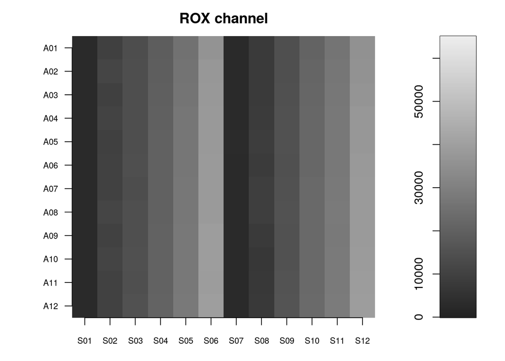

```r
# ----- Define a function for plotting a matrix ----- #
# from http://www.phaget4.org/R/image_matrix.html
myImagePlot <- function(x, ...){
     min <- 0
     max <- 65000
     yLabels <- rownames(x)
     xLabels <- colnames(x)
     title <-c()
  # check for additional function arguments
  if( length(list(...)) ){
    Lst <- list(...)
    if( !is.null(Lst$zlim) ){
       min <- Lst$zlim[1]
       max <- Lst$zlim[2]
    }
    if( !is.null(Lst$yLabels) ){
       yLabels <- c(Lst$yLabels)
    }
    if( !is.null(Lst$xLabels) ){
       xLabels <- c(Lst$xLabels)
    }
    if( !is.null(Lst$title) ){
       title <- Lst$title
    }
  }
# check for null values
if( is.null(xLabels) ){
   xLabels <- c(1:ncol(x))
}
if( is.null(yLabels) ){
   yLabels <- c(1:nrow(x))
}

layout(matrix(data=c(1,2), nrow=1, ncol=2), widths=c(4,1), heights=c(1,1))

 # Red and green range from 0 to 1 while Blue ranges from 1 to 0
 ColorRamp <- colorRampPalette(c('#222222', '#EEEEEE'))(n = 256)
 ColorLevels <- seq(min, max, length=length(ColorRamp))

 # Reverse Y axis
 reverse <- nrow(x) : 1
 yLabels <- yLabels[reverse]
 x <- x[reverse,]

 # Data Map
 par(mar = c(3,5,2.5,2))
 image(1:length(xLabels), 1:length(yLabels), t(x), col=ColorRamp, xlab="",
 ylab="", axes=FALSE, zlim=c(min,max))
 if( !is.null(title) ){
    title(main=title)
 }
axis(BELOW<-1, at=1:length(xLabels), labels=xLabels, cex.axis=0.7)
 axis(LEFT <-2, at=1:length(yLabels), labels=yLabels, las= HORIZONTAL<-1,
 cex.axis=0.7)

 # Color Scale
 par(mar = c(3,2.5,2.5,2))
 image(1, ColorLevels,
      matrix(data=ColorLevels, ncol=length(ColorLevels),nrow=1),
      col=ColorRamp,
      xlab="",ylab="",
      xaxt="n")

 layout(1)
}
# ----- END plot function ----- #



make_heatmap <- function(mat_data){

  color_scale <- colorRampPalette(c('#1A1A1A', '#EEEEEE'))(n = 256)

  # adjust the color scale. Max value sems to be around 65,000
  max_val <- max(mat_data)
  if (max_val > 65000){
    color_end <- 256
  }else{
    color_end <- round((max_val/65000) * 256)
  }
  color_scale <- color_scale[1:color_end]

  image(mat_data,
          axes=FALSE,
          col = color_scale,
          xlab='Assay',
          ylab='Sample')
}


# make a subset of the data frames for plotting
rox_data.df <- all.df[, which(names(all.df) %in% c('assay_well', 'sample_well', 'rox'))]
fam_data.df <- all.df[, which(names(all.df) %in% c('assay_well', 'sample_well', 'fam'))]

# make wide format
rox_data_wide.df <- dcast(rox_data.df, assay_well ~ sample_well, value.var='rox')
fam_data_wide.df <- dcast(fam_data.df, assay_well ~ sample_well, value.var='fam')

# use first column as row names
rox.mat_data <- data.matrix(rox_data_wide.df[, 2:length(names(rox_data_wide.df))])
rnames <- rox_data_wide.df[,'assay_well']   # assign labels in the "File" column to "rnames"
rownames(rox.mat_data) <- rnames

fam.mat_data <- data.matrix(fam_data_wide.df[, 2:length(names(fam_data_wide.df))])
rnames <- fam_data_wide.df[,'assay_well']   # assign labels in the "File" column to "rnames"
rownames(fam.mat_data) <- rnames


# Now make the heatmap
myImagePlot(rox.mat_data, title=('ROX channel'))
```

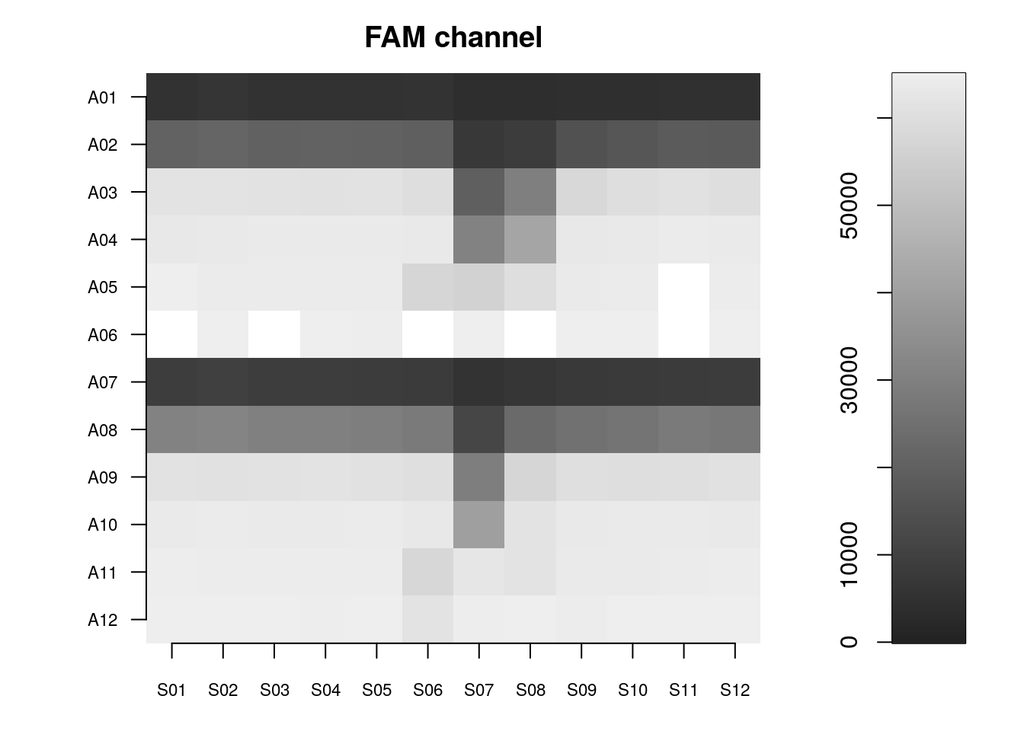

```r
myImagePlot(fam.mat_data, title=('FAM channel'))
```

Let’s plot all the ROX and FAM channel data.

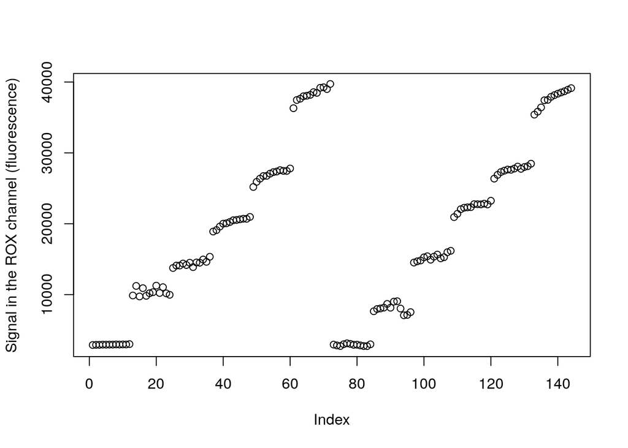

```r
plot(all.df$rox,
     ylab='Signal in the ROX channel (fluorescence)')
```

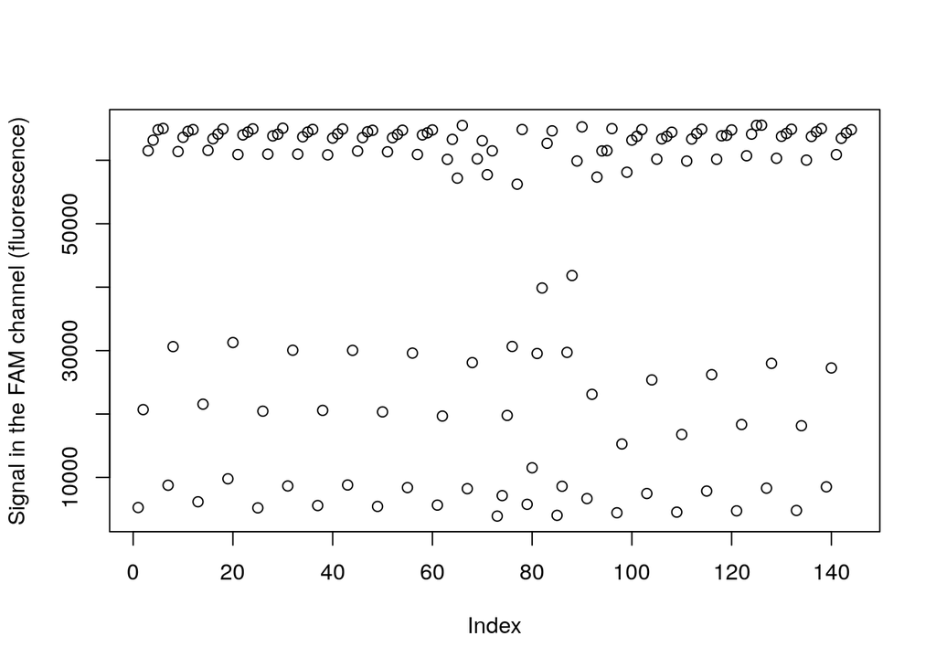

```r
plot(all.df$fam,
     ylab='Signal in the FAM channel (fluorescence)')
```

Now I want to see whether the resurofin is linear and whether the two Triton/Tween concentrations affect this linearity. Resurofin was loaded on the sample side.

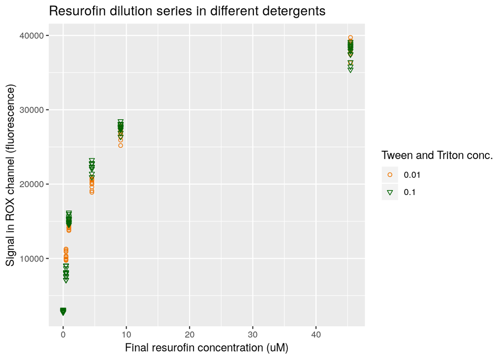

```r
ggplot(all.df, aes(x=final_resurofin_conc, y=rox, shape = factor(sample_tween_conc), color = factor(sample_tween_conc)))+
    geom_point() +
    scale_color_manual(values = c('0.01' = 'darkorange2', '0.1' = 'darkgreen'), name='Tween and Triton conc.') +
    scale_shape_manual(values = c('0.01' = 21, '0.1' = 25), name='Tween and Triton conc.') +
    ggtitle('Resurofin dilution series in different detergents') +
    xlab('Final resurofin concentration (uM)') +
    ylab('Signal in ROX channel (fluorescence)')
```

Let’s take a look at fluorescein now.

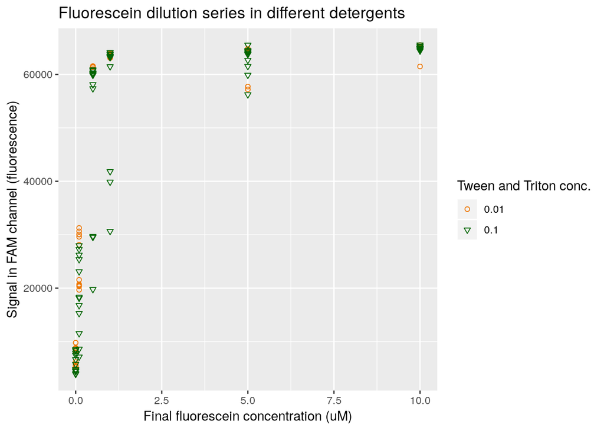

```r
ggplot(all.df, aes(x=final_fluorescein_conc, y=fam, shape = factor(sample_tween_conc), color = factor(sample_tween_conc)))+
    geom_point() +
    scale_color_manual(values = c('0.01' = 'darkorange2', '0.1' = 'darkgreen'), name='Tween and Triton conc.') +
    scale_shape_manual(values = c('0.01' = 21, '0.1' = 25), name='Tween and Triton conc.') +
    ggtitle('Fluorescein dilution series in different detergents') +
    xlab('Final fluorescein concentration (uM)') +
    ylab('Signal in FAM channel (fluorescence)')
```

There is certainly more of a spread here. If anything high detergent concentrations appear to disrupt the measurements. The detection is not linear at all. Both 0.1 and 0.5 uM are readily detectable. We decided to use 0.1 uM for fluorescein (final concentration) as loading control on both sample and assay side going forward. Missed loading can be detected as the signal should be halved.